# Test - extract environmental data for coordinates - package xyzt & friends

OHW 2022

2022-08-18

This is a test run using package xyzt (and derivatives for specific data sources) to extract e environmental data for coordinates of interest (e.g. sampling stations).  
I’m using my MSFD dataset for 2017, containing zoobenthic stations in the Bulgarian Black Sea sampled by IO-BAS for the national MSFD monitoring. There are separate coordinates for each replicate sample, sampling dates, and station depths in meters.

## Setup

Load necessary packages.

```r
library(tidyverse)
library(here)
library(sf)
library(ghrsst)
library(xyzt)
library(stars)
```

Define the working directory using package here (= project directory, ohw22-proj-xyzt), by giving it the path to the current file, relative to the project root.

```r
here::i_am("notebook/test_covars_extraction_with_xyzt.Rmd")
```

```
here() starts at /media/sklayn/data/data/rabota/kursove/ocean_hack_week_2022/ohw22-proj-xyzt
```

## Import data

Read in my example dataset (in the data subdirectory). It’s a csv file.

```r
(msfd <- read_csv(here("data", "msfd_2017_meta.csv")) %>%
     ## remove units from depth column name
     rename(depth = depth_m)
)
```

| station_code_repl | date | lat | lon | depth |
| --- | --- | --- | --- | --- |
| ZB1_1 | 2017-10-21 | 43.70905 | 28.64502 | 35.0 |
| ZB1_2 | 2017-10-21 | 43.70908 | 28.64468 | 35.0 |
| ZB3_1 | 2017-10-21 | 43.70857 | 28.85297 | 56.0 |
| ZB3_2 | 2017-10-21 | 43.70875 | 28.85288 | 56.0 |
| ZB5_1 | 2017-10-20 | 43.69460 | 29.26325 | 66.0 |
| ZB5_2 | 2017-10-20 | 43.69438 | 29.26332 | 66.0 |
| ZB11_1 | 2017-10-21 | 43.63672 | 28.60980 | 26.5 |
| ZB11_2 | 2017-10-21 | 43.63695 | 28.60972 | 26.5 |
| ZB14_1 | 2017-10-20 | 43.62188 | 28.98698 | 63.0 |
| ZB14_2 | 2017-10-20 | 43.62265 | 28.98603 | 63.0 |

[output cut: 161 more lines]

Transform to spatial points - ignore the dates and depths for now.

```r
(msfd.sp <- msfd %>%
    as_POINT(dims = "xy")
)
```

```
Simple feature collection with 171 features and 3 fields
Geometry type: POINT
Dimension:     XY
Bounding box:  xmin: 27.54567 ymin: 41.99233 xmax: 29.33717 ymax: 43.70908
Geodetic CRS:  WGS 84
```

|  | station_code_repl | date | depth | geometry |
| --- | --- | --- | --- | --- |
| 1 | ZB1_1 | 2017-10-21 | 35.0 |  |
| 2 | ZB1_2 | 2017-10-21 | 35.0 |  |
| 3 | ZB3_1 | 2017-10-21 | 56.0 |  |
| 4 | ZB3_2 | 2017-10-21 | 56.0 |  |
| 5 | ZB5_1 | 2017-10-20 | 66.0 |  |
| 6 | ZB5_2 | 2017-10-20 | 66.0 |  |
| 7 | ZB11_1 | 2017-10-21 | 26.5 |  |
| 8 | ZB11_2 | 2017-10-21 | 26.5 |  |
| 9 | ZB14_1 | 2017-10-20 | 63.0 |  |
| 10 | ZB14_2 | 2017-10-20 | 63.0 |  |

[output cut: 161 more lines]

## Extract data for points

Get the environmental data - in this case, SST from [GHRSST (Group for High Resolution Sea Surface Temperature)](https://www.ghrsst.org/). Several other variables are also available, but the time to get them all is fairly long, and I want to go through all dates and the corresponding points in the dataset in one go.

```r
## get the unique dates
dates <- msfd.sp %>% pull(date) %>% unique()

(msfd.sp.sst <- map(dates, function(x) {
    ## subset points to only those sampled on the current date
    msfd.sub <- msfd.sp %>%
        filter(date == x)


    ## generate a MUR url for the current date
    url <- mur_url(x)

    ## open the resource
    X <- ncdf4::nc_open(url)

    ## extract the data - only SST
    covars <- ghrsst::extract(msfd.sub, X, varname = "analysed_sst")

    ## bind to the input
    msfd.sub.sst <- dplyr::bind_cols(msfd.sub, covars)

    ## close the resource
    ncdf4::nc_close(X)

    return(msfd.sub.sst)

}) %>%

    ## put the dataset back together in a tibble
    bind_rows()
)
```

```
Simple feature collection with 171 features and 4 fields
Geometry type: POINT
Dimension:     XY
Bounding box:  xmin: 27.54567 ymin: 41.99233 xmax: 29.33717 ymax: 43.70908
Geodetic CRS:  WGS 84
```

|  | station_code_repl | date | depth | geometry | analysed_sst |
| --- | --- | --- | --- | --- | --- |
| 1 | ZB1_1 | 2017-10-21 | 35.0 |  | 291.056 |
| 2 | ZB1_2 | 2017-10-21 | 35.0 |  | 291.008 |
| 3 | ZB3_1 | 2017-10-21 | 56.0 |  | 291.022 |
| 4 | ZB3_2 | 2017-10-21 | 56.0 |  | 291.022 |
| 5 | ZB11_1 | 2017-10-21 | 26.5 |  | 291.068 |
| 6 | ZB11_2 | 2017-10-21 | 26.5 |  | 291.068 |
| 7 | ZB20_1 | 2017-10-21 | 44.0 |  | 291.249 |
| 8 | ZB20_2 | 2017-10-21 | 44.0 |  | 291.249 |
| 9 | ZB30_1 | 2017-10-21 | 67.0 |  | 291.263 |
| 10 | ZB30_2 | 2017-10-21 | 67.0 |  | 291.263 |

[output cut: 161 more lines]

Ok, seems fine.. Note how the SSTs look duplicated - because the replicate samples are so close to one another (in fact I wouldn’t really record 2 different sets of coordinates for replicates at the same station, but oh well, IO-BAS do this with their samples).

## Extract data for bounding box (from points)

Use the points’ spatial extent to construct a bounding box, then get the environmental data.  
This time, I’ll just use one date, and get all available parameters.

```r
msfd.bbox <- msfd %>%
    as_BBOX()
```

Get the environmental data.

```r
## generate a MUR url for the desired date - here, the first one (only one remaining for the bounding box)
url <- mur_url(msfd.bbox %>% pull(date))

## open the resource
X <- ncdf4::nc_open(url)

## extract data
(env.data <- ghrsst::extract(msfd.bbox, X, varnames = ghrsst::mur_vars(X)))
```

```
stars object with 2 dimensions and 5 attributes
attribute(s):
                     Min. 1st Qu.  Median        Mean 3rd Qu.    Max.  NA's
analysed_sst      290.119 291.131 291.612 291.4802735 291.874 292.483  7693
analysis_error      0.360   0.370   0.370   0.3711152   0.370   0.400  7693
mask                1.000   1.000   1.000   1.2477565   1.000   5.000     0
sea_ice_fraction       NA      NA      NA         NaN      NA      NA 31313
dt_1km_data       -37.000 -14.000  -9.000  -8.8320646  11.000  59.000 16075
dimension(s):
```

|  | from | to | offset | delta | refsys | point | values | x/y |
| --- | --- | --- | --- | --- | --- | --- | --- | --- |
| x | 1 | 181 | 27.5457 | 0.00989779 | WGS 84 | NA | NULL | [x] |
| y | 1 | 173 | 43.7091 | -0.00992341 | WGS 84 | NA | NULL | [y] |

```r
## close the connection
ncdf4::nc_close(X)
```

Plot the extracted SST and the points.

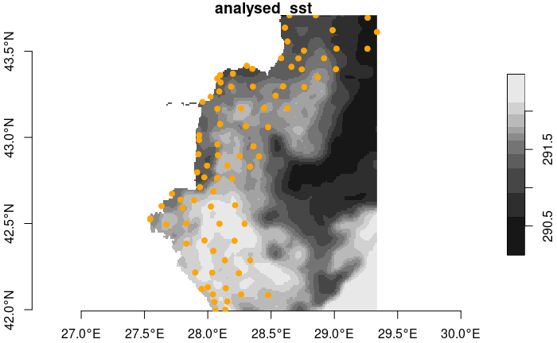

```r
plot(env.data, attr = 'analysed_sst', axes = TRUE, reset = FALSE)
plot(sf::st_geometry(msfd.sp), add = TRUE, col = "orange", pch = 19, cex = 0.9)
```